# Exercise Intro to R

Candace Savonen

2022-08-09

## Exercise 1: Installing packages from GitHub

1. Install a package called ‘devtools’.

```r
install.packages("devtools")
```

2. Attach the library of ‘devtools’.

```r
library(devtools)
```

3. Practice installing a package from github using this command:

This package can be seen here on GitHub: https://github.com/psolymos/KnockKnockJokes

```r
install_github("psolymos/KnockKnockJokes")
```

```
## Skipping install of 'KnockKnockJokes' from a github remote, the SHA1 (5096f515) has not changed since last install.
##   Use `force = TRUE` to force installation
```

4. You can use this package to tell you knock knock jokes by doing (remember to attach the library first).

```r
library(KnockKnockJokes)
KnockKnock()
```

```
## Knock-knock!
##  Who's there?
## Jamaica.
##  Jamaica who?
## Jamaica mistake?
```

## Exercise 2: Make a data frame from scratch.

1. Make a vector that has 5 items in it using this function: `c()`

```r
animals <- c("dog", "cat", "mouse", "elephant", "cheetah")
```

2. If you don’t know how to use this function look up the function with `?c`
3. Now make 2 more vectors that are also 5 items long in the same way.

```r
fur_colors <- c("brown", "orange", "gray", "dark gray", "spotted")
cuddliness <- c(5, 3, 3, 2, 0)
```

4. Take all 3 vectors and put them together in one data frame using this function:

```r
animals_df <- data.frame(animals, fur_colors, cuddliness)
```

5. Look at one of the columns using a `$` to pull out one of the variables you used to make this data frame.

```r
animals_df$animals
```

```
## [1] dog      cat      mouse    elephant cheetah
## Levels: cat cheetah dog elephant mouse
```

6. Use the `readr::write_csv()` function to write your data frame to a CSV file. Make sure that you specify the file name using the file argument. Look up documentation about write_csv using ? for more details. Remember to put the filename you specify needs to be put in quotes.

```r
dir.create("data")
readr::write_csv(animals_df, file = "data/animals.csv")
```

## Exercise 3: Read in data from googlesheets and make a basic plot

1. Take a look at these movies in this [googlesheet](https://docs.google.com/spreadsheets/d/1okTb4MTllkDWlj0daHNfA8RwOPhLQkWtpQN_znJJJmk/htmlview?hl=en).
2. Use the `googlesheets4` package and the `read_sheet` function to read in one of the sheets here. You can use the sheets argument to specify which sheet and genre you’d like to read in.

```r
install.packages("googlesheets4")
library(googlesheets4)

comedies <- read_sheet("https://docs.google.com/spreadsheets/d/1okTb4MTllkDWlj0daHNfA8RwOPhLQkWtpQN_znJJJmk/htmlview?hl=en", sheet = 2)
```

[output not shown]

[output not shown]

[output not shown]

[output not shown]

```
## ✔ Reading from "Greatest films of all time".
```

```
## ✔ Range ''CRIME''.
```

3. Using the `max()` function, find whats the most number of oscars won by a film in the genre you read in.

```r
max(comedies$`Oscars won`)
```

```
## [1] NA
```

4. Rename the Oscars column so it is called `oscars_won`.

```r
library(dplyr)
comedies <- rename(comedies, oscars_won = `Oscars won`)
```

5. Using the `dplyr::filter()` function filter to only movies that won Oscars. (Get rid of movies that have `NA` for Oscars)

This will look like this:

```r
dplyr::filter(comedies, !is.na(oscars_won))
```

```
## # A tibble: 5 × 9
##   Entry Film             Direc…¹ Leadi…² Year …³ oscar…⁴ IMDB …⁵ Guard…⁶ Country
##   <dbl> <chr>            <chr>   <chr>     <dbl>   <dbl> <chr>   <chr>   <chr>
## 1     1 Chinatown        Roman … Faye D…    1974       1 http:/… http:/… USA
## 2     8 Pulp Fiction     Quenti… Amanda…    1994       1 http:/… http:/… USA
## 3    10 Goodfellas       Martin… Frank …    1990       1 http:/… http:/… USA
## 4    12 Bonnie & Clyde   Arthur… Faye D…    1967       2 http:/… http:/… USA
## 5    14 French Connecti… Willia… Fernan…    1971       5 http:/… http:/… USA
## # … with abbreviated variable names ¹Director, ²`Leading actors`,
## #   ³`Year of cinema release`, ⁴oscars_won, ⁵`IMDB link`, ⁶`Guardian film page`
```

6. Assign this data frame as a new object.

```r
oscar_winning_comedies <- dplyr::filter(comedies, !is.na(oscars_won))
```

7. Use the plot() function to plot the number of oscars by movie. Where `x = Film` and `y = oscars_won`.

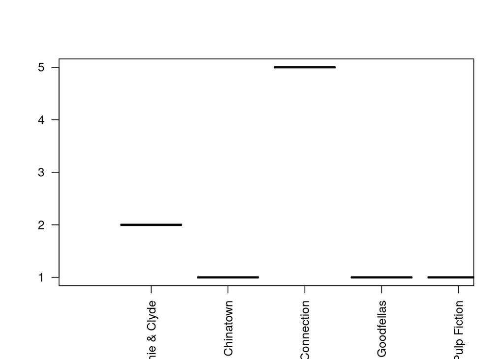

```r
plot(x = as.factor(oscar_winning_comedies$Film),
     y = as.numeric(oscar_winning_comedies$oscars_won),
     xlim = c(0,5),
     las = 2)
```

8. Save this plot to a PNG using the Export button.